# Poisson Process

Yuji Saikai ysaikai@unimelb.edu.au School of Mathematics and Statistics The University of Melbourne

These notes are based on Chapter 2 of Robert G. Gallager (2013). *Stochastic Processes: Theory for Applications*. Cambridge University Press.

The Poisson process is, in many ways, a continuous-time analogue of the Bernoulli process, a sequence of independent Bernoulli trials, which we use to motivate Binomial, Geometric, and Negative binomial. Here is a summary of correspondences between discrete-time and continuous-time analogues in different modelling contexts.

| Context | Discrete time | Continuous time |
| --- | --- | --- |
| Number of arrivals | Binomial | Poisson |
| Time to an arrival | Geometric | Exponential |
| Time to multiple arrivals | Negative binomial | Gamma |
| Arrival process | Bernoulli process | Poisson process |

> Here, “process” implies a stochastic process. For our purpose, it suffices to see a stochastic process as a function that maps an index to a random variable. An index set (i.e., the domain of a stochastic process) is typically a subset of Euclidean space. In the above case, a point in time is an index and an index set is a set of either positive integers or reals.

Let’s first define a couple of key concepts and review the Bernoulli process to motivate the Poisson process.

# Arrival process

An arrival process is a sequence of increasing random variables $0 < S_1 < S_2 < \dots$, where $S_1, S_2,\dots$ are called arrival epochs and represent successive times at which some random phenomenon occurs.

> In these notes, to avoid possible confusion, **epoch** is used as a synonym for time.

Any arrival process $\{S_n : n\geq 1\}$ can also be specified by either of the following alternative stochastic processes. The first one is a sequence of **interarrival times** $\{X_i : i\geq 1\}$. Each $X_i$ is a positive random variable defined in terms of the arrival epochs such that
$$X_1=S_1 \enspace\text{and}\enspace X_i=S_i-S_{i−1}, \enspace\forall i > 1.$$
Conversely, each arrival epoch $S_n$ for $n \geq 1$ is specified by $\{X_1,\dots,X_n\}$ as
$$S_n = \sum_{i=1}^n X_i.$$

> When the interarrival sequence is IID, an arrival process is often called **renewal process**. The Bernoulli process and the Poisson process are types of renewal process.

The second alternative is the counting process $\{N(t) : t>0\}$ where, for each $t>0$, the random variable $N(t)$ is the total number of arrivals over the time interval $(0,t]$.

> We assume $N(0)=0$ with probability 1 and focus on arrivals at strictly positive epochs.

The relations among three stochastic processes are easily seen in the following figure.

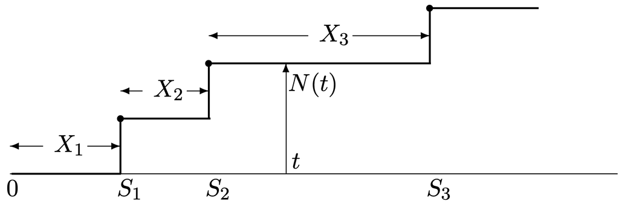

There are two key properties to emphasise. The first one is
$$N(t+\tau) \geq N(t) \enspace\text{for}\enspace \tau>0.$$

The second one, which is less obvious, is that the following events are equivalent:
$$\{S_n \leq t\} = \{N(t) \geq n\}$$
for $n \geq 1$ and $t > 0$. To see this, notice, on the one hand $S_n \leq t$ means that the $n$th arrival occurs by epoch $t$. On the other hand, $N(t) \geq n$ means that at least $n$ arrivals occurs by epoch $t$.

In short, an arrival process can be specified by one of the following stochastic processes:

- Arrival epochs $\{S_n\}$
- Interarrival times $\{X_i\}$
- Counting variables $\{N(t)\}$.

In the Bernoulli process and the Poisson process, $\{X_n\}$ is an IID sequence and a lot easier to handle than $\{S_n\}$ or $\{N(t)\}$.

# Discrete-time arrival process

Let $\{B_t : t\in\mathbb{Z}_{>0}\}$ denote the Bernoulli process, where each of independent trials is $B_t\sim\text{Bernoulli}(p)$. We may see the Bernoulli process as a discrete-time arrival process in the following way:

- Indices correspond to integer epochs $t\in\{1,2,\dots\}$ and represents time slots of equal length.
- At each slot, $\text{Bernoulli}(p)$ trial takes place.
- $B_t=1$ represents an arrival (previously, “success”).

The corresponding stochastic processes are:

- $S_n$ : the total number of slots until the $n$th arrival.
- $X_i$ : the number of slots taken between the $i$th and $(i-1)$th arrivals.
- $N(t)$ : the number of arrivals over $t$ slots.

It is straightforward to derive:
$$\begin{align}
S_n &\sim \text{nbinom}(n,p)\\
X_i &\sim \text{geom}(p)\\
N(t) &\sim \text{binom}(t,p)
\end{align}$$

> N.B. Here, $\text{geom}(p)$ and $\text{nbinom}(n,p)$ are based on the number of **trials** instead of **failures**.

Again the figure is pretty helpful.

[figure not shown]

# Definition & properties

The Poisson process is a continuous-time arrival process $\{S_n\}$ where each of the interarrival time follows an IID exponential sequence, i.e., $X_i\sim\text{exp}(\lambda)$ for all $i\in\mathbb{Z}_{>0}$. Perhaps, you may think that, in the discrete-time setting, we check whether an arrival happens exactly every minute $(t\in\mathbb{Z}_{>0})$. In the continuous-time setting, instead, we can monitor arrivals all the time $(t\in\mathbb{R}_{>0})$.

In the discrete-time setting, it is straightforward to define an arrival process using $\text{Bernoulli}(p)$ because an arrival occurs with probability $p>0$. In contrast, in the continuous-time setting, the probability of arrival at any particular moment is $0$. As a result, we cannot define an arrival process in the same straightforward way. It is more convenient to deﬁne a Poisson process indirectly in terms of the sequence of IID interarrival times $X_1,X_2,\dots$.

## Property 1

In the Poisson counting process $\{N(t) : t>0\}$, the number of arrivals over $(0,t]$ follows $\text{pois}(\lambda t)$ with the PMF of
$$P(N(t)=n) = \frac{e^{-\lambda t}(\lambda t)^n}{n!}.$$

*Proof*. A key observation is that $N(t)=n$ if and only if $S_n \leq t < S_{n+1}$ because the $n$th arrival occurs before time $t$ but the $(n+1)$th occurs after $t$. Also remember that, by definition, $X_{n+1}$ is independent of $X_1,\dots,X_n$ and therefore independent of $S_n=X_1+\dots+X_n$.

$$\begin{align}
P(N(t)=n)
&= P(S_n \leq t < S_{n+1})\\
&= P(S_n \leq t, S_{n+1} > t)\\
&= P(S_n \leq t, X_{n+1} > t-S_n)\\
&= \int_0^t\int_{t-s}^\infty f(s,x)dxds\\
&= \int_0^t\int_{t-s}^\infty f_{S_n}(s)f_X(x)dxds \quad (\because X_{n+1} \perp\!\!\!\perp S_n)\\
&= \int_0^t f_{S_n}(s)\left[\int_{t-s}^\infty f_X(x)dx\right]ds\\
&= \int_0^t \lambda e^{-\lambda s}\frac{(\lambda s)^{n-1}}{(n-1)!}\cdot e^{-\lambda(t-s)}ds\\
&= \frac{(\lambda)^{n}}{(n-1)!}e^{-\lambda t} \int_0^t s^{n-1}ds\\
&= \frac{e^{-\lambda t}(\lambda t)^{n}}{n!}
\end{align}$$

> Recall $S_n=X_1+\dots+X_n$ follows $\text{gamma}(n,\lambda )$.

## Property 2

For $\tau\geq0$, $N(t+\tau)-N(t)$ follows $\text{pois}(\lambda \tau)$.

*Proof*. Suppose that, by time $t$, there have been $n$ arrivals at time $s_1, \dots, s_n$. We know $X_{n+1}>t-s_n$. In addition, by the memoryless property of $\text{exp}(\lambda)$,
$$P(X_{n+1}>t-s_n+\tau | X_{n+1}>t-s_n) = P(X_{n+1}>\tau) = e^{-\lambda \tau}.$$
This implies that the distribution of the first arrival **after $t$** also follows $\text{exp}(\lambda)$ and independent of $S_1,\dots,S_n$. It is also the case that $X_{n+2}, X_{n+3},\dots$ are independent of $S_1,\dots,S_n$ and $X_{n+1}$. Consequently, a sequence of interarrival times after $t$ is an IID $\text{exp}(\lambda)$ and forms a Poisson process. Hence, the claim.

## Property 3

$N(t)$ has independent increments; i.e., for $t_0<t_1<\dots<t_n$,
$$N(t_n)-N(t_{n-1}), N(t_{n-1})-N(t_{n-2}), \dots, N(t_1)-N(t_0)$$
are independent.

*Proof*. Property 2 implies that $N(t_n)-N(t_{n-1})$ is independent of $N(s)$ for $s\leq t_{n-1}$ and therefore independent of $N(t_{n-1})-N(t_{n-2}), \dots, N(t_1)-N(t_0).$

> As is often the case in mathematics, we have a choice of definitions from which the other properties are derived. So, we can use the above peoperties as a definition of Poisson process and derive the IID exponential interarrival times.

# Applications

## Compounding

If you run a tech company that provides online services (e.g., shopping and banking), you need computer servers to respond to customers’ requests. These days, it has become quite popular to rent, rather than buy, computing infrastructure in the cloud. Just like your mobile phone contracts, you want to rent a right amount of the infrastructure. To figure out the right amount, you need models of customers’ requests.

Let’s take one step at a time.

1. Model how many customers arrive each day.
2. Model how many requests each customer makes.

Combining them, we have a random variable for the total number of request per day. Most likely, we are interested in its mean and variance.

- Let $N$ be a random variable for the number of customers per day.
- Let $Y_1,Y_2,\dots$ be IID random variables such that $Y_n$ is the number of requests the $n$th customer makes.
- Let $S = Y_1+\dots+Y_N$ and $S=0$ when $N=0$. This is of our interest.
- Assume $N$ and each $Y_n$ are independent.

Then, implications are:

1. $\mathbb{E}S = \mathbb{E}N \cdot \mathbb{E}Y_n$ provided $\mathbb{E}N, \mathbb{E}Y_n < \infty$.
2. $\operatorname{Var} S = \mathbb{E}N \cdot \operatorname{Var} Y_n + \operatorname{Var} N \cdot (\mathbb{E}Y_n)^2$ provided $\mathbb{E}N^2, \mathbb{E}Y_n^2 < \infty$.
3. If the customer arrival process follows the Poisson process with rate $\lambda$, then $\operatorname{Var} S = \lambda\mathbb{E}(Y_n)^2$.

*Proof for (i).*
$$\begin{align}
\mathbb{E}S &= \sum_{n=0}^\infty \mathbb{E}[S|N=n]\cdot P(N=n)\\
&= \sum_{n=0}^\infty \mathbb{E}[Y_1+\dots+Y_n|N=n]\cdot P(N=n)\\
&= \sum_{n=0}^\infty n\mathbb{E}Y_n \cdot P(N=n)\\
&= \mathbb{E}N \cdot \mathbb{E}Y_n
\end{align}$$

*Proof for (ii).* First, for given $N=n$,
$$\begin{align}
\mathbb{E}[S^2|N=n] &= \operatorname{Var}[S|N=n] + (\mathbb{E}[S|N=n])^2\\
&= n\operatorname{Var}Y_n + n^2(\mathbb{E}Y_n)^2
\end{align}$$

Then,
$$\begin{align}
\mathbb{E}S^2 &= \sum_{n=0}^\infty \mathbb{E}[S^2|N=n] \cdot P(N=n)\\
&= \sum_{n=0}^\infty \left(n\operatorname{Var}Y_n + n^2(\mathbb{E}Y_n)^2\right) \cdot P(N=n)\\
&= \mathbb{E}N\cdot\operatorname{Var}Y_n + \mathbb{E}N^2\cdot(\mathbb{E}Y_n)^2
\end{align}$$

As a result,
$$\begin{align}
\operatorname{Var}S &= \mathbb{E}S^2 - (\mathbb{E}S)^2\\
&= \mathbb{E}N\cdot\operatorname{Var}Y_n + \mathbb{E}N^2\cdot(\mathbb{E}Y_n)^2 - (\mathbb{E}N \cdot \mathbb{E}Y_n)^2\\
&= \mathbb{E}N\cdot\operatorname{Var}Y_n + \operatorname{Var}N \cdot (\mathbb{E}Y_n)^2
\end{align}$$

*Proof for (iii)*. We are interested in the Poisson counting process for $t=1$. Thus, we have $N \sim \text{pois}(\lambda)$, which implies $\mathbb{E}N = \lambda$ and $\operatorname{Var}N = \lambda$. Now, the result follows from (ii).

## Splitting

Suppose you use a Poisson process with rate $\lambda$ per hour to model an arrival process of customers during the happy hour. You also know roughly $100p$% of customers are women. Now, you wonder what arrival processes will emerge from the following simulations:

1. Simulate the overall customer arrival process using the original Poisson process, and
2. Randomly assign to each arrival female with probability $p$ and male with probability $1-p$.

Interestingly, both women and men arrival processes are again Poisson processes with rate $p\lambda$ and $(1-p)\lambda$ respectively, and they are **independent**. Notice, if the splitting is conditioned on $N(t)=n$, it will be simply $N_w(t) \sim \text{binom}(n,p)$, and $N_m(t)=n-N_w(t)$ is clearly dependent on $N_w(t)$. Doesn’t this come as a surprise?

Let’s examine both counting processes $\{N_w(t)\}$ and $\{N_m(t)\}$. Here, we use three properties to show they are Poisson processes.

*Proof*. First, since the random assignment is independent of any other randomness, the independent increments property of the original process implies that the increments
$$N_s(t_n)-N_s(t_{n-1}), N_s(t_{n-1})-N_s(t_{n-2}), \dots, N_s(t_1)-N_s(t_0)$$
are independent of each other for $s\in\{w,m\}$. Second, by definition, $N_w(0) = N_m(0) = 0$. Hence, we only need to show that $N_w(t+\tau)-N_w(t)$ and $N_m(t+\tau)-N_m(t)$ both follow correct Poisson distributions and are independent of each other.